# ExerciseQualityAssessment

CMLPR

January 30, 2016

# 1 Executive Summary

The goal of this study is to use data from accelerometers on the belt, forearm, arm, and dumbell of 6 participants and quantify *how well they did the exercise*. *Classe* variable in the training set defines the quality of the exercise. Classe *A* is used when the person does the exercise correctly and Classe *B:E* are used to specify the mistake type in the case of poor quality. For more information please refer to (Velloso et al. 2013) and [Human Activity Recognition](http://groupware.les.inf.puc-rio.br/har#dataset).

A set of training data set will be used to train various machine learning algorithms and then performance of the fitted models will be tested on a test data set.

# 2 Load Packages

In this project I will use mainly the _caret_package for ML and *dplyr* for certain data manipulations. I also prefer to use *doMC* package to reduce the computation time.

```r
require(caret);require(doMC);require(dplyr);require(rpart);require(rpart.plot)
# Register parallel cores for use in training to reduce time consumption.
registerDoMC(cores = 6)
```

# 3 Load Data

Use *read.table* function to load data. A quick look at the *csv* file can show that there are many cells with NA values and some cells with division error. It is best to read both of them as *NAs*. Also after data is stored, *user_name* and *classe* columns are converted to factors. Testing data is also brought in for later use.

```r
# Read Training Data
rData <- read.table("pml-training.csv", header = TRUE, sep = ",", na.strings = c("NA", "#DIV/0!"), stringsAsFactors = FALSE)
rData = mutate(rData, user_name = as.factor(user_name),
                      classe    = as.factor(classe))
dim(rData)
```

```
## [1] 19622   160
```

```r
table(rData$classe)
```

```
##
##    A    B    C    D    E
## 5580 3797 3422 3216 3607
```

```r
table(rData$user_name)
```

```
##
##   adelmo carlitos  charles   eurico   jeremy    pedro
##     3892     3112     3536     3070     3402     2610
```

```r
# Read Testing Data
rTesting <- read.table("pml-testing.csv", header = TRUE, sep = ",", na.strings = c("NA", "#DIV/0!"), stringsAsFactors = FALSE)
```

# 4 Pre-Processing

## 4.1 Data Cleaning

The data set includes some columns that needs to be removed to create a robust model. Some column types that are removed can be summarized as follows:

- Columns that have substantial number of *NA’s*. Fraction of NA counts in each column are calculated. It was observed that 100 columns have over 97% NAs in them while the remaining 60 columns don’t have any NAs in them.
- Since the data is associated with time stamps it makes sense to preserve timestamps for training the data and applying time slicing for cross validation. However response variable defining the quality is given for each observation and test set provided for 20 independent observations. Therefore, it doesn’t make much sense to use the first column, timestamp columns and window columns (window columns are used by the authors of the original article for training)

```r
# Remove columns with substantial NAs
NAfraction <- sapply(rData, function(x) {sum(is.na(x)) / length(x)})
table(NAfraction)
```

```
## NAfraction
##                 0 0.979308938946081 0.979359902150647 0.979410865355213
##                60                67                 1                 1
## 0.979512791764346 0.979563754968912 0.979767607787178 0.979818570991744
##                 1                 4                 1                 4
##  0.97986953419631 0.980939761492203 0.983233105697686 0.983284068902253
##                 2                 2                 1                 1
## 0.983385995311385 0.983538884925084  0.98358984812965 0.983640811334217
##                 2                 1                 4                 2
##                 1
##                 6
```

```r
cData <- rData[, NAfraction < 0.5] # 50% threshold will capture everything

colsToRemove <- c("X", "raw_timestamp_part_1", "raw_timestamp_part_2", "cvtd_timestamp", "new_window", "num_window")
cData <- cData[, !(colnames(cData) %in% colsToRemove)]

dim(cData)
```

```
## [1] 19622    54
```

```r
names(cData)
```

```
##  [1] "user_name"            "roll_belt"            "pitch_belt"
##  [4] "yaw_belt"             "total_accel_belt"     "gyros_belt_x"
##  [7] "gyros_belt_y"         "gyros_belt_z"         "accel_belt_x"
## [10] "accel_belt_y"         "accel_belt_z"         "magnet_belt_x"
## [13] "magnet_belt_y"        "magnet_belt_z"        "roll_arm"
## [16] "pitch_arm"            "yaw_arm"              "total_accel_arm"
## [19] "gyros_arm_x"          "gyros_arm_y"          "gyros_arm_z"
## [22] "accel_arm_x"          "accel_arm_y"          "accel_arm_z"
## [25] "magnet_arm_x"         "magnet_arm_y"         "magnet_arm_z"
## [28] "roll_dumbbell"        "pitch_dumbbell"       "yaw_dumbbell"
## [31] "total_accel_dumbbell" "gyros_dumbbell_x"     "gyros_dumbbell_y"
## [34] "gyros_dumbbell_z"     "accel_dumbbell_x"     "accel_dumbbell_y"
## [37] "accel_dumbbell_z"     "magnet_dumbbell_x"    "magnet_dumbbell_y"
## [40] "magnet_dumbbell_z"    "roll_forearm"         "pitch_forearm"
## [43] "yaw_forearm"          "total_accel_forearm"  "gyros_forearm_x"
## [46] "gyros_forearm_y"      "gyros_forearm_z"      "accel_forearm_x"
## [49] "accel_forearm_y"      "accel_forearm_z"      "magnet_forearm_x"
## [52] "magnet_forearm_y"     "magnet_forearm_z"     "classe"
```

## 4.2 Center and Scale Data

- It is always a good idea to standardize the data to reduce imbalance in magnitudes. Caret’s *prePreocess* function can be used with *center* and *scale* arguments.

```r
preScale <- preProcess(cData[, names(cData) != "classe"], method = c("center", "scale"))
training <- predict(preScale, cData[, names(cData) != "classe"])
```

## 4.3 Prepare Test Set

- Drop columns to match training data. Additionally we don’t have response variable in the training data
- Apply data centering and scaling

```r
# Drop columns
trainingColumns <- names(cData)[names(cData) != "classe"]
cTesting <- subset(rTesting, select = trainingColumns)

# Scaling
testing <- predict(preScale, cTesting)
```

# 5 Model Building and Prediction

## 5.1 Random Forest Algorithm

Now that we have both training and test data ready for the machine learning implementation, we can build a Random Forest model first. Cross-Validation with 10 folds will also be used during training RF model for better fit and to get out of sample error rates.

```r
# Get resonse
resp <- cData$classe
set.seed(13625)
fitControl <- trainControl(method = "cv",
                           number = 10,
                           allowParallel = TRUE)
set.seed(587456)
rfFit <- train(resp ~.,
               method="rf",
               data=training,
               trControl = fitControl)
```

### 5.1.1 RF Model Performance

- We can get model accuracy for each hold-out set using *rfFit$resample*. Mean accuracy for the 10 fold CV is 0.9949 and out of sample error is 0.0051 (0.5%).
- *r confusionMatrix.train* will provide the confusion matrix for the final model selected during training.
- When final model is used to estimate the training accuracy on the whole training data, we observe an accuracy of 1.
- In general the accuracy rate generated by the RF model is very high and a little suspicious suggestiong overfitting.

```r
rfFit
```

```
## Random Forest
##
## 19622 samples
##    52 predictor
##     5 classes: 'A', 'B', 'C', 'D', 'E'
##
## No pre-processing
## Resampling: Cross-Validated (10 fold)
## Summary of sample sizes: 17661, 17659, 17660, 17659, 17659, 17659, ...
## Resampling results across tuning parameters:
##
##   mtry  Accuracy   Kappa      Accuracy SD  Kappa SD
##    2    0.9947001  0.9932957  0.001596030  0.002018964
##   29    0.9949041  0.9935539  0.001357416  0.001717181
##   57    0.9899096  0.9872354  0.001840973  0.002328967
##
## Accuracy was used to select the optimal model using  the largest value.
## The final value used for the model was mtry = 29.
```

```r
kfoldacc <- rfFit$resample
mean(kfoldacc$Accuracy)
```

```
## [1] 0.9949041
```

```r
confusionMatrix.train(rfFit)
```

```
## Cross-Validated (10 fold) Confusion Matrix
##
## (entries are percentages of table totals)
##
##           Reference
## Prediction    A    B    C    D    E
##          A 28.4  0.1  0.0  0.0  0.0
##          B  0.0 19.2  0.1  0.0  0.0
##          C  0.0  0.0 17.3  0.1  0.0
##          D  0.0  0.0  0.1 16.3  0.0
##          E  0.0  0.0  0.0  0.0 18.3
```

```r
pred_train <- predict(rfFit, newdata = training)
confusionMatrix(pred_train, resp)
```

```
## Confusion Matrix and Statistics
##
##           Reference
## Prediction    A    B    C    D    E
##          A 5580    0    0    0    0
##          B    0 3797    0    0    0
##          C    0    0 3422    0    0
##          D    0    0    0 3216    0
##          E    0    0    0    0 3607
##
## Overall Statistics
##
##                Accuracy : 1
##                  95% CI : (0.9998, 1)
##     No Information Rate : 0.2844
##     P-Value [Acc > NIR] : < 2.2e-16
##
##                   Kappa : 1
##  Mcnemar's Test P-Value : NA
##
## Statistics by Class:
##
##                      Class: A Class: B Class: C Class: D Class: E
## Sensitivity            1.0000   1.0000   1.0000   1.0000   1.0000
## Specificity            1.0000   1.0000   1.0000   1.0000   1.0000
## Pos Pred Value         1.0000   1.0000   1.0000   1.0000   1.0000
## Neg Pred Value         1.0000   1.0000   1.0000   1.0000   1.0000
## Prevalence             0.2844   0.1935   0.1744   0.1639   0.1838
## Detection Rate         0.2844   0.1935   0.1744   0.1639   0.1838
## Detection Prevalence   0.2844   0.1935   0.1744   0.1639   0.1838
## Balanced Accuracy      1.0000   1.0000   1.0000   1.0000   1.0000
```

```r
treeModel <- rpart(resp ~ ., data=training, method="class")
prp(treeModel)
```

[figure not shown]

### RF Prediction

- Finally we can use a new set to predict exercise quality.

```r
pred <- predict(rfFit, testing)
pred
```

```
##  [1] B A B A A E D B A A B C B A E E A B B B
## Levels: A B C D E
```

# 6 Appendix Section

## 6.1 K-Nearest Neighbors

I would like to use KNN as a second model. In this case, let’s first start by dividing the training data into a new training and test sets. Then one can check the distributions of classes in each data set to make sure that each class is distributed uniformly among the datasets. This time *repeatedcv* with 10 folds and 3 repeates will be used. K value for the KNN will be investigated for a list of values ranging from 1 to 15.

```r
set.seed(100)
newTraining <- mutate(training, classe = resp)
inTrain <- createDataPartition(y = newTraining$classe, p = 0.75, list = FALSE)
trainKNN <- newTraining[inTrain,]
testKNN  <- newTraining[-inTrain,]
dim(trainKNN)
```

```
## [1] 14718    54
```

```r
dim(testKNN)
```

```
## [1] 4904   54
```

```r
#check the distribution
prop.table(table(trainKNN$classe))
```

```
##
##         A         B         C         D         E
## 0.2843457 0.1935046 0.1744123 0.1638810 0.1838565
```

```r
prop.table(table(testKNN$classe))
```

```
##
##         A         B         C         D         E
## 0.2844617 0.1935155 0.1743475 0.1639478 0.1837276
```

```r
prop.table(table(newTraining$classe))
```

```
##
##         A         B         C         D         E
## 0.2843747 0.1935073 0.1743961 0.1638977 0.1838243
```

```r
#Training Control
#Repeated CV; K=10 folds, 3 repeats
#NPV(negative predictive val) should be used as the metric.
set.seed(200)
trainControl <- trainControl(method = "repeatedcv", number = 10, repeats = 3,
                             classProbs = TRUE, allowParallel = TRUE)
tuningGrid <- expand.grid(k=c(1,3,5,7,10,15))
knn.fit <- train(classe ~ ., data = trainKNN,
                 method = "knn",
                 trControl = trainControl,
                 preProcess = c("center", "scale"),
                 metric = "Accuracy",
                 tuneGrid = tuningGrid)
```

### 6.1.1 KNN Model Performance

```r
knn.fit
```

```
## k-Nearest Neighbors
##
## 14718 samples
##    53 predictor
##     5 classes: 'A', 'B', 'C', 'D', 'E'
##
## Pre-processing: centered (57), scaled (57)
## Resampling: Cross-Validated (10 fold, repeated 3 times)
## Summary of sample sizes: 13247, 13246, 13247, 13247, 13244, 13245, ...
## Resampling results across tuning parameters:
##
##   k   Accuracy   Kappa      Accuracy SD  Kappa SD
##    1  0.9890605  0.9861632  0.002751848  0.003480452
##    3  0.9768526  0.9707208  0.004114933  0.005204406
##    5  0.9638976  0.9543280  0.004899494  0.006197552
##    7  0.9547256  0.9427149  0.006550765  0.008285421
##   10  0.9359273  0.9189114  0.007865766  0.009952342
##   15  0.9122151  0.8888780  0.009566092  0.012104875
##
## Accuracy was used to select the optimal model using  the largest value.
## The final value used for the model was k = 1.
```

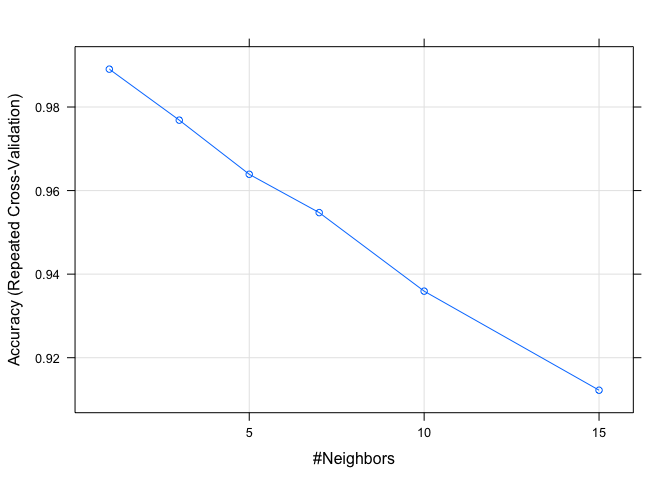

```r
plot(knn.fit)
```

```r
#Predict
knn.predict <- predict(knn.fit, newdata = testKNN)
confusionMatrix(knn.predict, testKNN$classe)
```

```
## Confusion Matrix and Statistics
##
##           Reference
## Prediction    A    B    C    D    E
##          A 1388    8    0    0    0
##          B    5  936    2    1    0
##          C    2    5  841    7    2
##          D    0    0   12  796    1
##          E    0    0    0    0  898
##
## Overall Statistics
##
##                Accuracy : 0.9908
##                  95% CI : (0.9877, 0.9933)
##     No Information Rate : 0.2845
##     P-Value [Acc > NIR] : < 2.2e-16
##
##                   Kappa : 0.9884
##  Mcnemar's Test P-Value : NA
##
## Statistics by Class:
##
##                      Class: A Class: B Class: C Class: D Class: E
## Sensitivity            0.9950   0.9863   0.9836   0.9900   0.9967
## Specificity            0.9977   0.9980   0.9960   0.9968   1.0000
## Pos Pred Value         0.9943   0.9915   0.9813   0.9839   1.0000
## Neg Pred Value         0.9980   0.9967   0.9965   0.9980   0.9993
## Prevalence             0.2845   0.1935   0.1743   0.1639   0.1837
## Detection Rate         0.2830   0.1909   0.1715   0.1623   0.1831
## Detection Prevalence   0.2847   0.1925   0.1748   0.1650   0.1831
## Balanced Accuracy      0.9964   0.9921   0.9898   0.9934   0.9983
```

- K = 1 yields the best result with Accuracy 98.9%. OOB error is 1.1% for te training data.
- Findal model yields 99.08% accuracy on test data with 0.92% OOB error.

### 6.1.2 KNN Prediction

- Let’s use the KNN model fit on small test data.

```r
pred <- predict(knn.fit, testing)
pred
```

```
##  [1] B A B A A E D B A A B C B A E E A B B B
## Levels: A B C D E
```

- Predictions are same as the RF model’s predictions.

Velloso, Eduardo, Andreas Bulling, Hans Gellersen, Wallace Ugulino, and Hugo Fuks. 2013. “Qualitative Activity Recognition of Weight Lifting Exercises.” *Proceedings of 4th International Conference in Cooperation with SIGCHI*. ACM SIGCHI.